# A little statistics

## Problem 1

#### A) A normal distribution is a distribution of data that follows a "bell curve," not being biased towards the left or right.

```python
# Part B
import math
print("Zero SD away from mean: " + str(math.erf(0)))
print("One SD away from mean: " + str(math.erf(1/2**0.5)))
print("Two SDs away from mean: " + str(math.erf(2/2**0.5)))
print("Three SDs away from mean: " + str(math.erf(3/2**0.5)))
print("Five SDs away from mean: " + str(math.erf(5/2**0.5)))
```

```
Zero SD away from mean: 0.0
One SD away from mean: 0.6826894921370859
Two SDs away from mean: 0.9544997361036416
Three SDs away from mean: 0.9973002039367398
Five SDs away from mean: 0.9999994266968563
```

```python
# Part C
import scipy.stats as stats
print("0.5 of the data, should be near 0: " + str(stats.norm.ppf(0.5)))
print("0.84 of the data, should be near 1: " + str(stats.norm.ppf(0.84)))
print("0.975 of the data, should be near 2: " + str(stats.norm.ppf(0.975)))
print("0.99999971334 of the data, should be near 5: " + str(stats.norm.ppf(0.99999971334)))
```

```
0.5 of the data, should be near 0: 0.0
0.84 of the data, should be near 1: 0.994457883209753
0.975 of the data, should be near 2: 1.959963984540054
0.99999971334 of the data, should be near 5: 4.99999433116949
```

#### D) No minus sign appeared.

## Problem 2

#### A) The chi-squared distribution is comprised of the sum of 'k' different normally distributed random variables, each one independently squared, where 'k' is the degrees of freedom specified.

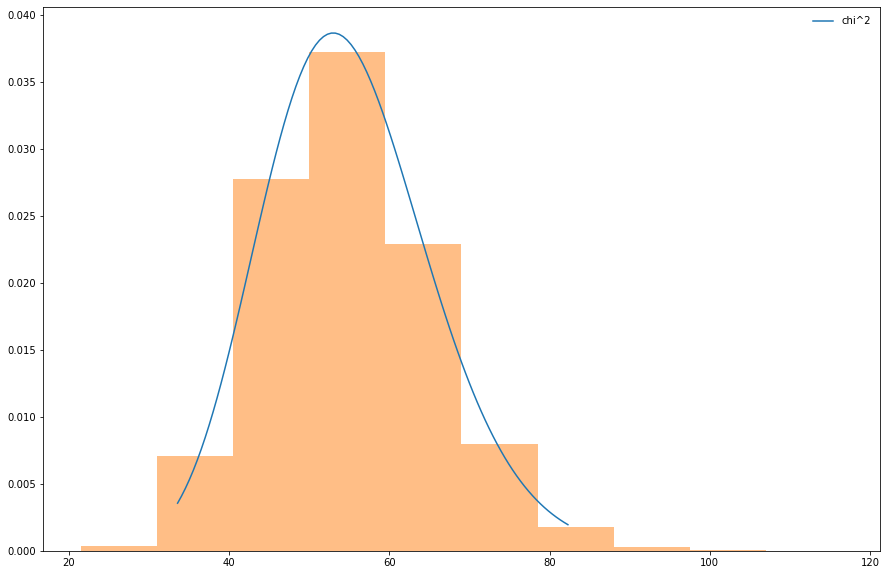

```python
# Part B
import matplotlib.pyplot as plt
from scipy.stats import chi2
import numpy as np

#plt.rcParams["figure.figsize"] = (15,10)
fig, ax = plt.subplots(1, 1)

df = 55 #degrees of freedom, not sure what to set but 55 works as a default

x = np.linspace(chi2.ppf(0.01, df),
                chi2.ppf(0.99, df), 100)
ax.plot(x, chi2.pdf(x, df), label='chi^2')

r = chi2.rvs(df, size=100000)
ax.hist(r, density=True, histtype='stepfilled', alpha=0.5)
ax.legend(loc='best', frameon=False)
plt.show()
```

## Problem 3

#### A) Selecting 40 as value.

#### B) What is the chance that a value at or below 40 will be selected given the chi-squared distribution shown in Problem 2?

#### C) Integral from -infinity to 40 of f, where f is the chi-squared distribution defined above.

```python
# Part D
prob = chi2.cdf(40, 55)
print("Probability that a value at or below 40 will be selected is: " + str(prob))
# Part E
print("This is equivalent to a sigma of " + str(stats.norm.ppf(prob)))
```

```
Probability that a value at or below 40 will be selected is: 0.06417199712845423
This is equivalent to a sigma of -1.520664728636832
```

## Problem 4

```python
# Testing part of Problem 4, change n to value being checked and run to see the values of probability and sigma.
n = 150
probability = chi2.cdf(n, 55)
print("Probability: " + str(probability) + " and sigma: " + str(stats.norm.ppf(probability)))
```

```
Probability: 0.9999999999039542 and sigma: 6.367533841605463
```

# Non-continuous Distributions

## Problem 1

#### A) A binomial distribution is the discrete probability distribution of the number of expected successes given a probability p (from 0 to 1) and a number of independent experiments n.

```
[[<AxesSubplot:> <AxesSubplot:>]
 [<AxesSubplot:> <AxesSubplot:>]]
```

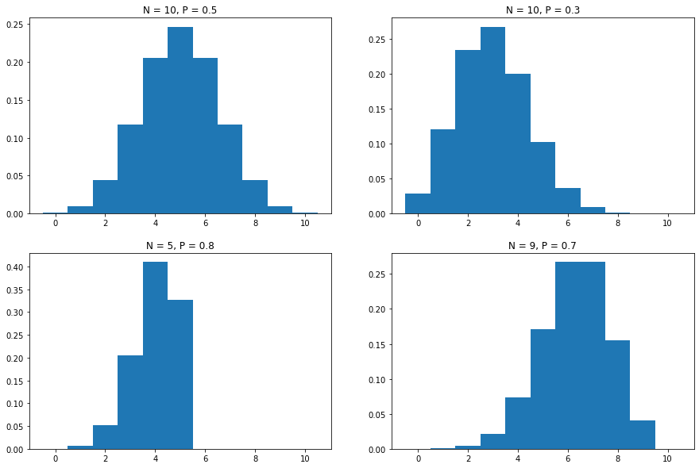

```python
# Part B
from scipy.stats import binom

fig, ax = plt.subplots(2, 2)
print(ax)
n, p = 10, 0.5
x = np.linspace(0,10,11)
ax[0,0].bar(x, binom.pmf(x, n, p), width=1)
ax[0,0].title.set_text("N = 10, P = 0.5")
ax[0,1].bar(x, binom.pmf(x, 10, 0.3), width=1)
ax[0,1].title.set_text("N = 10, P = 0.3")
ax[1,0].bar(x, binom.pmf(x, 5, 0.8), width=1)
ax[1,0].title.set_text("N = 5, P = 0.8")
ax[1,1].bar(x, binom.pmf(x, 9, 0.7), width=1)
ax[1,1].title.set_text("N = 9, P = 0.7")
```

```python
# Part C
print("Probability to get greater than or equal to 7 successes in 10 tries if the probability of"
      + " each success is 0.6 is: " + str(1-binom.cdf(x, 10, 0.6)[7]))
```

[output not shown]

#### D) Having discrete probabilities and "sigmas" means that there are a limited number of possibilities for certain values (such as the mode), which allows you to do things such as finding the probability of something with simple addition rather than integrals. Additionally, it allows people to manually do calculations that might be incredibly difficult otherwise, as many values are limited to easy to work with values.

#### E) It makes sense that some parameters can change continuously because they're based on the probabilities of any given outcome, which are not limited to discrete values. Parameters such as the mean can change continuously because their calculations involve the probabilities of individual outcomes, while parameters such as the range cannot change continuously because they are based on the values that are measured themselves.